# Project 1 EDA: NYC Weather Data

Emily

2022-10-01

##EDA with NYC Weather Data

```r
#loading packages and data

NYweath <- data.frame(read.csv("NYC_weather_1869_2022.csv"))
xkablesummary(NYweath)
```

Table: Statistics summary.

|  | STATION | NAME | LATITUDE | LONGITUDE | ELEVATION | DATE | ACMH | ACSH | AWND | DAEV | DASF | DAWM | EVAP | FMTM | MDEV | MDSF | MDWM | PGTM | PRCP | PSUN | SNOW | SNWD | TAVG | TMAX | TMIN | TOBS | TSUN | WDF1 | WDF2 | … |
| --- | --- | --- | --- | --- | --- | --- | --- | --- | --- | --- | --- | --- | --- | --- | --- | --- | --- | --- | --- | --- | --- | --- | --- | --- | --- | --- | --- | --- | --- | --- |
| Min | Length:56093 | Length:56093 | Min. :40.8 | Min. :-74 | Min. :42.7 | Length:56093 | Min. : 0 | Min. : 0 | Min. : 0 | Min. :2 | Min. :2 | Min. :2 | Min. :0 | Min. : 0 | Min. :0 | Min. : 0 | Min. : 7 | Min. : 0 | Min. :0.00 | Min. : 0 | Min. : 0.0 | Min. : 0 | Min. : 0 | Min. : 2.0 | Min. :-15.0 | Min. :60 | Min. : 0 | Min. : 10 | Min. : 0 | … |
| Q1 | Class :character | Class :character | 1st Qu.:40.8 | 1st Qu.:-74 | 1st Qu.:42.7 | Class :character | 1st Qu.: 30 | 1st Qu.: 20 | 1st Qu.: 4 | 1st Qu.:2 | 1st Qu.:2 | 1st Qu.:3 | 1st Qu.:0 | 1st Qu.: 1045 | 1st Qu.:0 | 1st Qu.: 2 | 1st Qu.: 57 | 1st Qu.: 952 | 1st Qu.:0.00 | 1st Qu.: 18 | 1st Qu.: 0.0 | 1st Qu.: 0 | 1st Qu.:43 | 1st Qu.: 46.0 | 1st Qu.: 34.0 | 1st Qu.:60 | 1st Qu.: 48 | 1st Qu.:110 | 1st Qu.: 80 | … |
| Median | Mode :character | Mode :character | Median :40.8 | Median :-74 | Median :42.7 | Mode :character | Median : 50 | Median : 50 | Median : 6 | Median :3 | Median :2 | Median :3 | Median :0 | Median : 1450 | Median :0 | Median : 4 | Median : 84 | Median :1440 | Median :0.00 | Median : 63 | Median : 0.0 | Median : 0 | Median :57 | Median : 63.0 | Median : 47.0 | Median :61 | Median : 420 | Median :230 | Median :240 | … |
| Mean | NA | NA | Mean :40.8 | Mean :-74 | Mean :42.7 | NA | Mean : 52 | Mean : 52 | Mean : 6 | Mean :3 | Mean :2 | Mean :3 | Mean :0 | Mean : 1445 | Mean :0 | Mean : 5 | Mean : 99 | Mean :1364 | Mean :0.12 | Mean : 56 | Mean : 0.1 | Mean : 0 | Mean :56 | Mean : 61.5 | Mean : 46.8 | Mean :61 | Mean : 395 | Mean :196 | Mean :199 | … |
| Q3 | NA | NA | 3rd Qu.:40.8 | 3rd Qu.:-74 | 3rd Qu.:42.7 | NA | 3rd Qu.: 80 | 3rd Qu.: 80 | 3rd Qu.: 8 | 3rd Qu.:3 | 3rd Qu.:2 | 3rd Qu.:3 | 3rd Qu.:0 | 3rd Qu.: 1850 | 3rd Qu.:1 | 3rd Qu.: 7 | 3rd Qu.:129 | 3rd Qu.:1834 | 3rd Qu.:0.05 | 3rd Qu.: 92 | 3rd Qu.: 0.0 | 3rd Qu.: 0 | 3rd Qu.:71 | 3rd Qu.: 78.0 | 3rd Qu.: 62.0 | 3rd Qu.:62 | 3rd Qu.: 641 | 3rd Qu.:280 | 3rd Qu.:290 | … |
| Max | NA | NA | Max. :40.8 | Max. :-74 | Max. :42.7 | NA | Max. :100 | Max. :100 | Max. :23 | Max. :4 | Max. :2 | Max. :4 | Max. :7 | Max. :32767 | Max. :1 | Max. :40 | Max. :294 | Max. :2359 | Max. :8.28 | Max. :100 | Max. :27.3 | Max. :26 | Max. :92 | Max. :106.0 | Max. : 87.0 | Max. :62 | Max. :2352 | Max. :760 | Max. :360 | … |
| NA | NA | NA | NA | NA | NA | NA | NA’s :55362 | NA’s :55363 | NA’s :46312 | NA’s :55964 | NA’s :56037 | NA’s :55971 | NA’s :54028 | NA’s :46050 | NA’s :55964 | NA’s :56037 | NA’s :55971 | NA’s :47015 | NA | NA’s :51300 | NA’s :163 | NA’s :16499 | NA’s :53445 | NA’s :7 | NA’s :7 | NA’s :56091 | NA’s :46878 | NA’s :51751 | NA’s :46562 | … |

```r
#str(NYweath)
#cablehead(NYweath, n=5)
#tail(NYweath, n=2)
```

```r
#converting to R date format and adding columns for day, month, and year
NYweath$DATE <- as.Date(NYweath$DATE)
NYweath$day <- format(NYweath$DATE, format="%d")
NYweath$month <- format(NYweath$DATE, format="%m")
NYweath$year <- format(NYweath$DATE, format="%Y")

#converting temperature observations to numerics
NYweath$TMAX <- as.numeric(NYweath$TMAX)
NYweath$TMIN <- as.numeric(NYweath$TMIN)
NYweath$TAVG <- as.numeric(NYweath$TAVG)
NYweath$year <- as.numeric(NYweath$year)

#Making month a factor
NYweath$month <- as.factor(NYweath$month)

#creating a subset of the weather data that are only date- and temperature-related
NYweath_temp <- subset(NYweath, select = c(DATE, day, month, year, TMAX, TMIN, TAVG, PRCP, SNOW))
xkablesummary(NYweath_temp)
```

[output not shown]

## First attempt to visualize temperature trends

Let’s try to plot the max temp recorded each day in Central Park over time.

[figure not shown]

```r
NYweath_temp %>%
  ggplot(aes(x = DATE, y = TMAX)) +
    geom_point() +
    ggtitle("Minimum Daily Temperature in Central Park")
```

And the minimum.

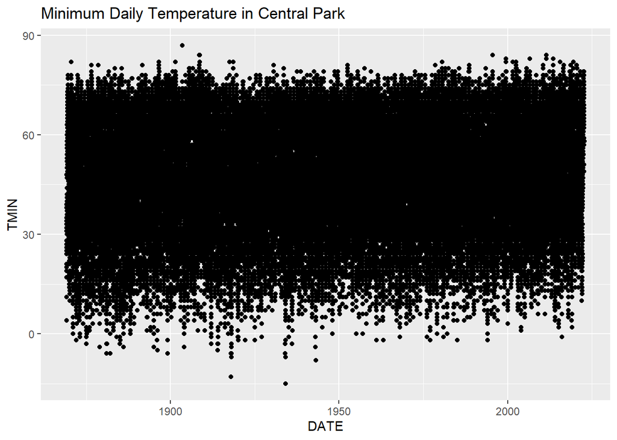

```r
NYweath_temp %>%
  ggplot(aes(x = DATE, y = TMIN)) +
    geom_point() +
    ggtitle("Minimum Daily Temperature in Central Park")
```

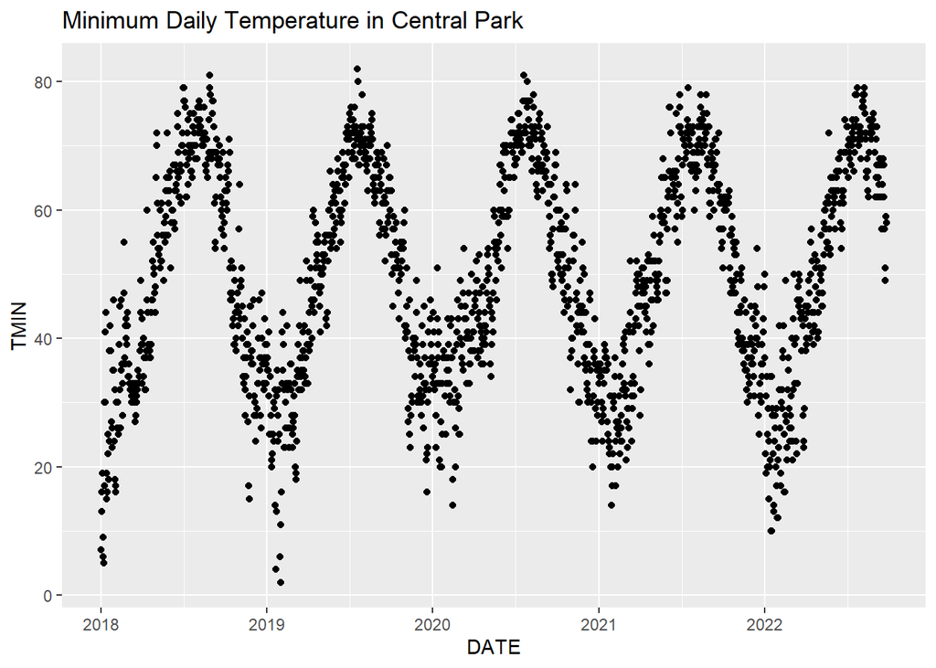

```r
Recent_weath <- subset(NYweath_temp, year > 2017)
Recent_weath %>%
  ggplot(aes(x = DATE, y = TMIN)) +
    geom_point() +
    ggtitle("Minimum Daily Temperature in Central Park")
```

How reassuring! Now, let’s look at the maximum daily temperatures.

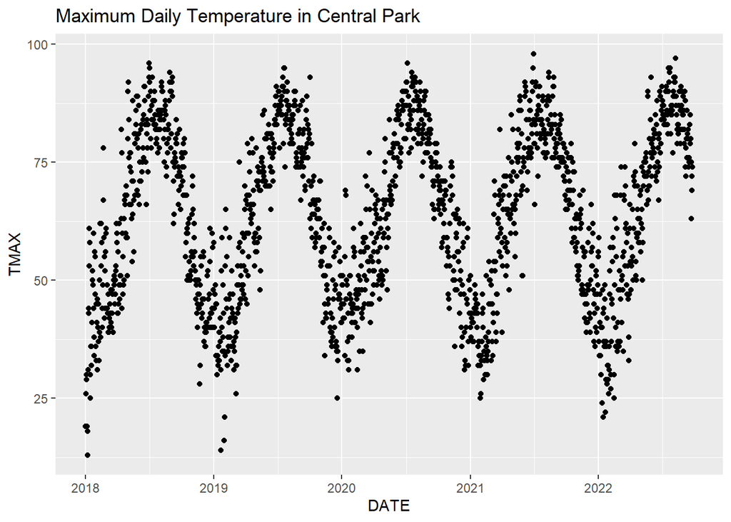

```r
Recent_weath <- subset(NYweath_temp, year > 2017)
Recent_weath %>%
  ggplot(aes(x = DATE, y = TMAX)) +
    geom_point() +
    ggtitle("Maximum Daily Temperature in Central Park")
```

Cool. We could fit these data to sine curves to determine the amplitudes or center points of oscillation along with confidence intervals, and compare them to the results for way earlier in the 20th or 19th centuries, to see if there are statistical differences in the curve fit parameters across the 100-year window.

What about trends in daily temperature range (daily high minus daily low)?

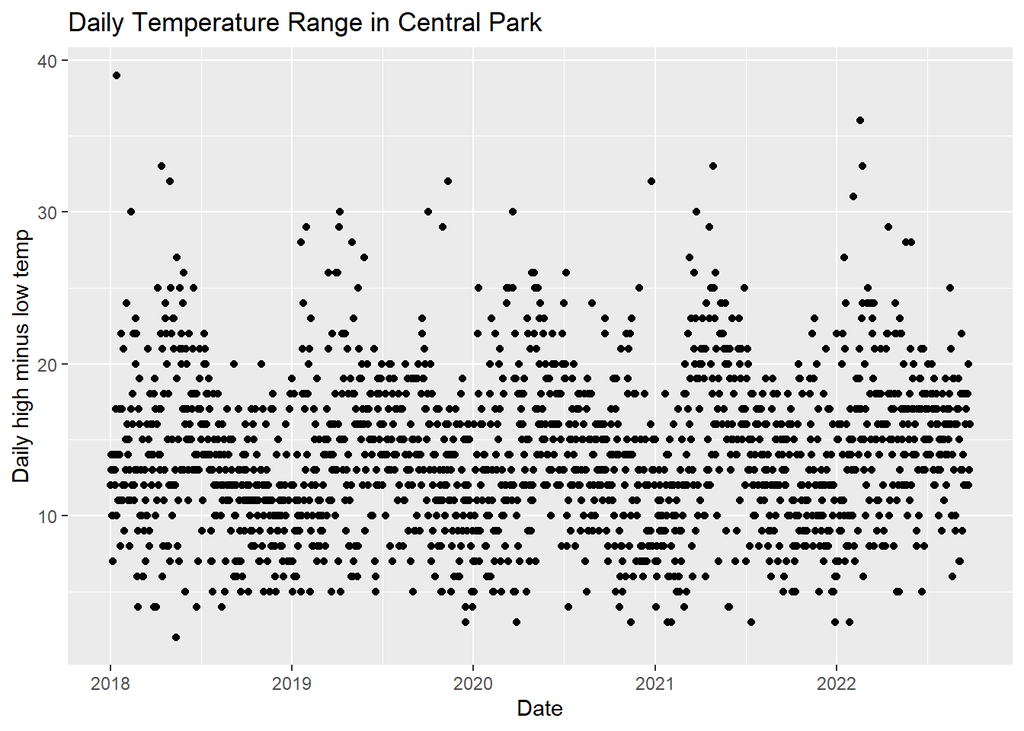

```r
Recent_weath$rang <- (Recent_weath$TMAX - Recent_weath$TMIN)

Recent_weath %>%
  ggplot(aes(x = DATE, y = rang)) +
  geom_point() +
  labs(
    title = "Daily Temperature Range in Central Park",
    x = "Date",
    y = "Daily high minus low temp")
```

Interesting… I do see a trend here too: the greatest daily variation in temperature in Central Park appears to occur in later winter/early spring. We could compute the average daily temperature variation for each month, perhaps over the 100 year interval, to see if some months have statistically higher daily temperature variations.

Now, for long-term trends, let’s look at Just the month of June.

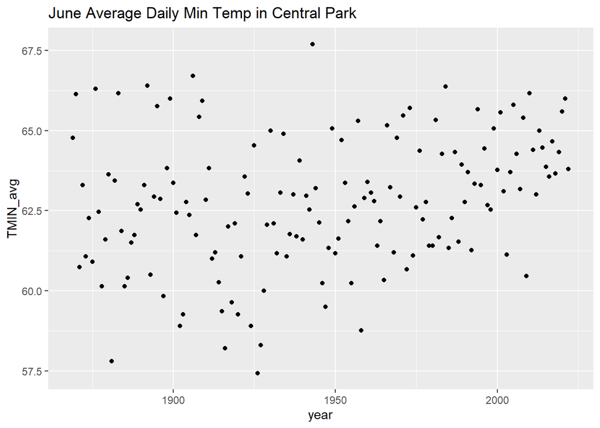

```r
#creating a subset of the weather data that are just for June
NYweath_temp_June <- subset(NYweath_temp, month == "06")

#setting up a for loop to compute avg June Daily Low Temp
ans = NULL
ans2 = NULL
for (n in 1869:2022) {
    ans <- mean(NYweath_temp_June[NYweath_temp_June$year == n, 'TMIN'], na.rm=TRUE)
    ans2 <- c(ans2, ans)
}

#Creating new data frame containing only the data we want to plot
NYmintemp_June <- data.frame(year = c(1869:2022), TMIN_avg = ans2)

#plotting the average daily low temperature in June from 1869 - 2022
NYmintemp_June %>%
  ggplot(aes(x = year, y = TMIN_avg)) +
    geom_point() +
    ggtitle("June Average Daily Min Temp in Central Park")
```

There does seem to be maybe a trend… but if so it is subtle… could attempt a linear fit and compute regression statistics. Could also do hypothesis testing on whether the avg June high temps from 1900-1910 are significantly distinct from those from 2000 to 2010. Would be very interesting to see trends also from a weather station in a more urban (concrete + steel) part of NYC.

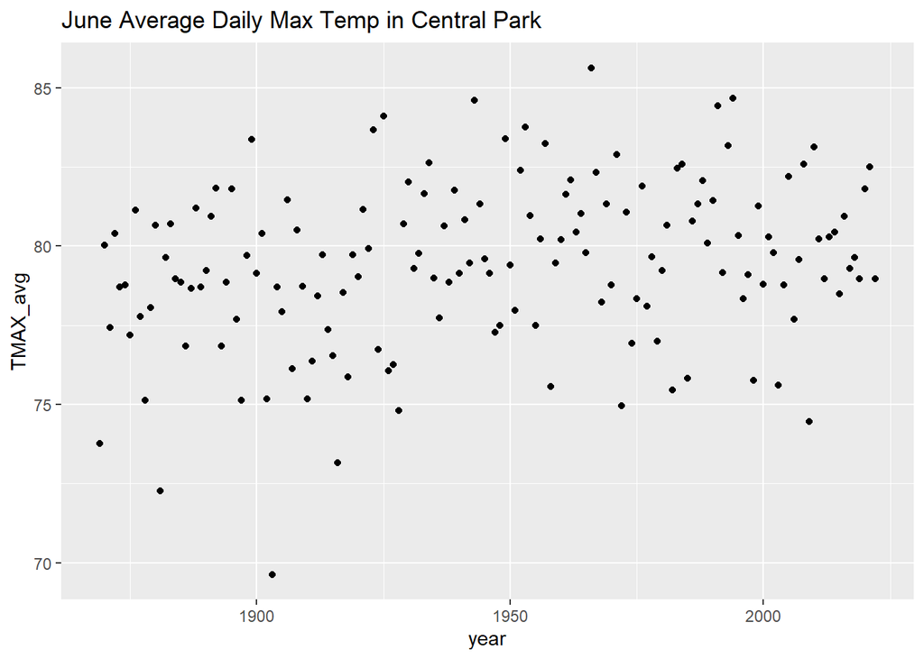

```r
#setting up a for loop to compute avg June Daily High Temp
ansh = NULL
ansh2 = NULL
for (n in 1869:2022) {
    ansh <- mean(NYweath_temp_June[NYweath_temp_June$year == n, 'TMAX'], na.rm=TRUE)
    ansh2 <- c(ansh2, ansh)
}

NYmaxtemp_June <- data.frame(year = c(1869:2022), TMAX_avg = ansh2)

NYmaxtemp_June %>%
  ggplot(aes(x = year, y = TMAX_avg)) +
    geom_point() +
    ggtitle("June Average Daily Max Temp in Central Park")
```

Also seems like a slightly positive trend. Would be interesting to fit this to a linear model and look at slope & regression statistics, and to compare avg values for a cluster of years in the 1900s v. the 2000s.

##Modeling Let’s look at linear regression of these data.

```r
linfit_max <- lm(NYmaxtemp_June$TMAX_avg ~ NYmaxtemp_June$year)
summary(linfit_max)
```

[output not shown]

```r
maxTfit1 <- lm(formula = TMAX ~ year + month, data = NYweath_temp )
summary(maxTfit1)
```

[output not shown]

The multiple r-squared (and adjusted r-squared) fits are much better here, at 0.775. This may simply be because there are many more data points than when using monthly averages. So– that full mess of data was all useful!

Here are the equations:

January: -23.3 + 0.0316 `year`  
February: -23.3+ 1.38 + 0.0316 `year`  
March: -23.3 + 9.55 + 0.0316 `year`  
April: -23.3 + 21.2 + 0.0316 `year`  
May: -23.3 + 32.3 + 0.0316 `year`  
June: -23.3 + 41.1 + 0.0316 `year`  
July: -23.3 + 46.1 + 0.0316 `year`  
August: -23.3 + 44.1 + 0.0316 `year`  
September: -23.3 + 37.4 + 0.0316 `year`  
October: -23.3 + 26.2 + 0.0316 `year`  
November: -23.3 + 14.1 + 0.0316 `year`  
December: -23.3 + 3.71 + 0.0316 `year`

On average, maximum daily temperatures in this location in central park have been increasing by 0.0316 degrees Fahrenheit per year over the time frame of the data set (1869 to 2022).

```r
maxTfit2 <- lm(formula = TMAX ~ year*month, data = NYweath_temp )
summary(maxTfit2)
```

[output not shown]

I wonder if we’ll get something different if we look at weather in a more built environment. Starting a new RMD file for this.